# PCV Serotyping Analysis - Manuscript

### Compiled July 1, 2020 by Sweta Patel

**Updated January 21, 2021 by Sweta Patel**

*This markdown file contains the code and output for the results included in the PCV serotyping manuscript. There is a separate R file containing the data cleaning code used to generate the csv files used here. Please note that we ran a number of different models while working on this project; all prior models and code are saved in dated files in the Box folder.*

General order of steps:

- 1. Load clean csv files and R packages
- 2. Get numbers for Table 1 (demographics), Figure 1 (serotype class by year), and supplemental table 1 (serotypes by year)
- 3. Statistical analysis of serotype trends over time using multinomial logistic regression

## Importing data

```r
sero_cov <- read.csv("sero_cov.csv")
sero_demo <- read.csv("sero_demo.csv")
pna_test <- read.csv("Pneumonia Study - Micro Data - MAY-26-2020.csv")
micro_sp <- read.csv("micro_sp2.csv")

#Unclear why there is a new X variable in some of our datasets; will remove
sero_cov$X <- NULL
sero_demo$X <- NULL
micro_sp$X <- NULL
```

## Samples tested

*How many samples and children were tested for S. pneumo?*

First, will get this info for the pneumonia study.

Our variable of interest in the pna_test df is “sp_qpcr.” If sp_qpcr > 0, that means S.pneumo was detected. Will create a new binary variable for simplification.

```r
class(pna_test$sp_qpcr)   #numeric variable
```

```
## [1] "numeric"
```

```r
pna_test$sp_detect <- 99
pna_test$sp_detect [pna_test$sp_qpcr == 0] <- "No"
pna_test$sp_detect [pna_test$sp_qpcr > 0] <- "Yes"

#Looked at pna_test dataframe and the variable looks good, but will confirm
table(pna_test$sp_detect)   #225 No, 351 Yes
```

```
##
##  No Yes
## 225 351
```

```r
table(pna_test$sp_detect, pna_test$sp_qpcr)   #clunky but confirms all our Nos match with values of 0, and all our Yes's match with values > 0
```

[output not shown]

[output cut: 13 more lines]

[output not shown]

```r
225 + 351
```

```
## [1] 576
```

```r
351 / 576
```

```
## [1] 0.609375
```

Each child in the pneumonia study was swabbed once. 351/576 children (61%) tested positive for S.pneumo.

Next, will use our micro_sp df to get this info for the infant microbiome study. Our micro_sp df contains 265 rows, each with 10 opportunities for SP testing = 2650 opportunities. We summed the missing values to see how many samples should return a result for SP testing (either positive or negative), which we will confirm.

The sp_detect variable in the micro_sp df is binary and will tell us if a child had any positive NP samples. Sp_tot tells us the number of times SP was detected in each child; we will sum sp_tot to get the total # of positive samples.

```r
sum(is.na(micro_sp)) #732 missing values
```

```
## [1] 732
```

```r
2650 - 732
```

```
## [1] 1918
```

```r
#We should have 1918 samples from 265 children that were tested for S. pneumo in the infant microbiome study.

table(micro_sp$sp_detect)   #This gives us 66 No values and 199 Yes values
```

```
##
##  No Yes
##  66 199
```

```r
sum(micro_sp$spdet_tot, na.rm = TRUE) #953
```

```
## [1] 953
```

```r
#to confirm our numbers add up: get sum of the individual binary variables and manually add together
sapply(micro_sp, function(x) length(which(x == 1)))
```

```
##  study_id sp_detect   spdet_0   spdet_1   spdet_2   spdet_3   spdet_4   spdet_5
##         0         0         4        55        88       108       119       114
##   spdet_6   spdet_8  spdet_10  spdet_12 spdet_tot
##       119       127       115       104        33
```

```r
4 + 55 + 88 + 108 + 119 + 114 + 119 + 127 + 115 + 104   #sum is 953, consistent with what we got using our spdet_tot variable
```

```
## [1] 953
```

```r
#further confirmation: sum our negatives
sapply(micro_sp, function(x) length(which(x == 0)))
```

```
##  study_id sp_detect   spdet_0   spdet_1   spdet_2   spdet_3   spdet_4   spdet_5
##         0         0       257       175       131        94        74        70
##   spdet_6   spdet_8  spdet_10  spdet_12 spdet_tot
##        59        41        36        28        66
```

```r
257 + 175 + 131 + 94 + 74 + 70 + 59 + 41 + 36 + 28    #sum of negative samples = 965
```

```
## [1] 965
```

```r
953 + 965   #1918; fits with our calculations above. Success!
```

```
## [1] 1918
```

**Summary of samples tested:**

Total # children tested: 576 + 265 = 841

Total # children with at least 1 NP swab positive for SP: 351 (pna study) + 199 (microbiome study) = 550

Total # samples tested: 576 (pna study) + 1918 (microbiome study) = 2494

Total # samples positive for SP: 351 (pna study) + 953 (microbiome study) = 1304 (52% of tested samples)

Samples from 316 of these children underwent serotyping –> 268 strains isolated from 221 children and included in this analysis.

## Demographics

We are interested in age, sex, HIV status, and number PCV doses received for the children in this study.

```r
#Overall demographics for all 221 children
table(sero_demo$sex)
```

```
##
##   F   M
## 110 111
```

```r
prop.table(table(sero_demo$sex))
```

```
##
##         F         M
## 0.4977376 0.5022624
```

```r
summary(sero_demo$age_months)
```

```
##    Min. 1st Qu.  Median    Mean 3rd Qu.    Max.
##  0.9247  2.6571  6.0003  8.0795 12.2000 23.9000
```

```r
table(sero_demo$HIV_exp)
```

```
##
##  EI  EU  UU
##   9  63 141
```

```r
prop.table(table(sero_demo$HIV_exp))
```

```
##
##         EI         EU         UU
## 0.04225352 0.29577465 0.66197183
```

```r
table(sero_demo$prevnar)
```

```
##
##  0  1  2  3
## 91 29 23 77
```

```r
91+29+23+77
```

```
## [1] 220
```

```r
sum(is.na(sero_demo$prevnar)) #only 1 child missing data
```

```
## [1] 1
```

```r
prop.table(table(sero_demo$prevnar))  #FYI with conventional rounding, percentages sum to 99, not 100
```

```
##
##         0         1         2         3
## 0.4136364 0.1318182 0.1045455 0.3500000
```

```r
#~58% children included received =>1 dose PCV13 prior to swab collection.
```

Was there a difference by serotype class (PCV-13 vs non-PCV-13)?

```r
table(sero_cov$ca13)  #134 strains in each serotype class
```

```
##
## Not_PCV13     PCV13
##       134       134
```

```r
#sex
table(sero_cov$sex, sero_cov$ca13)
```

```
##
##     Not_PCV13 PCV13
##   F        74    60
##   M        60    74
```

```r
prop.table(table(sero_cov$sex, sero_cov$ca13), 2)
```

```
##
##     Not_PCV13     PCV13
##   F 0.5522388 0.4477612
##   M 0.4477612 0.5522388
```

```r
summary(table(sero_cov$sex, sero_cov$ca13))
```

```
## Number of cases in table: 268
## Number of factors: 2
## Test for independence of all factors:
##  Chisq = 2.9254, df = 1, p-value = 0.0872
```

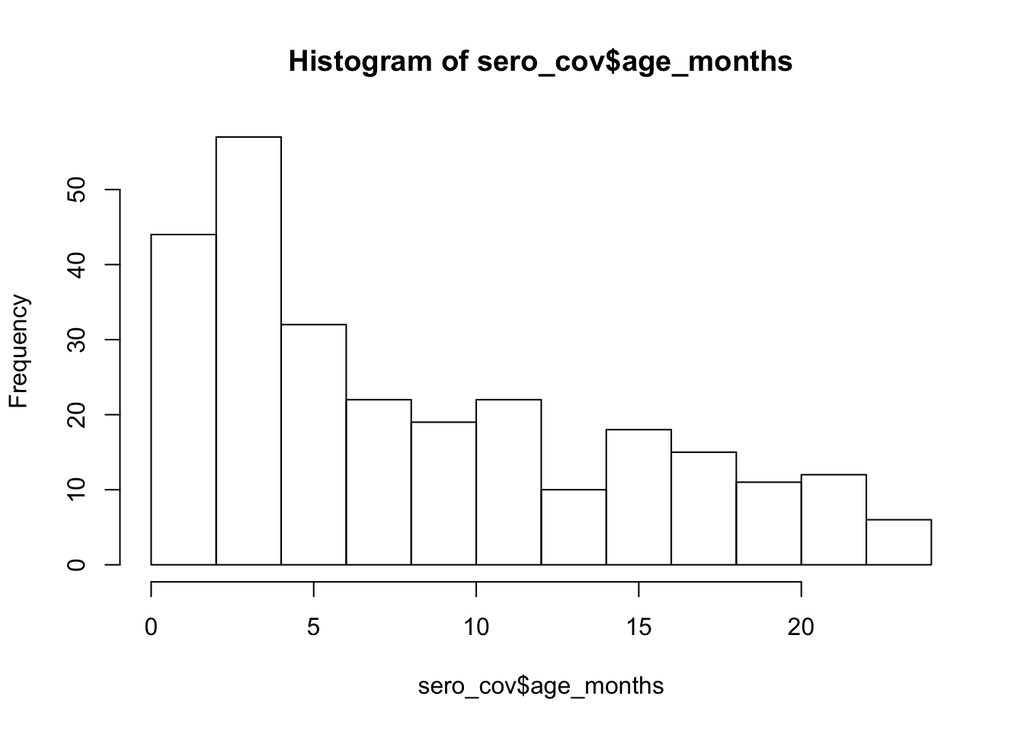

```r
#age
hist(sero_cov$age_months)  #Our age distribution is skewed, so we will use a non-parametric test (MW) when looking for differences by serotype class
```

```r
summary(sero_cov$age_months)
```

```
##    Min. 1st Qu.  Median    Mean 3rd Qu.    Max.
##  0.9247  2.5845  6.0003  8.1446 12.2000 23.9000
```

```r
tapply(sero_cov$age_months, sero_cov$ca13, summary)
```

```
## $Not_PCV13
##    Min. 1st Qu.  Median    Mean 3rd Qu.    Max.
##  0.9247  2.0638  4.1131  6.9321 10.1594 23.8000
##
## $PCV13
##    Min. 1st Qu.  Median    Mean 3rd Qu.    Max.
##  0.9247  3.3000  7.9500  9.3572 14.4000 23.9000
```

```r
wilcox.test(sero_cov$age_months ~ sero_cov$ca13)
```

```
##
##  Wilcoxon rank sum test with continuity correction
##
## data:  sero_cov$age_months by sero_cov$ca13
## W = 6820, p-value = 0.000672
## alternative hypothesis: true location shift is not equal to 0
```

```r
#HIV exposure status
#Need to recode the blank cells in the HIV_exp variable as NA to get accurate proportions (as was done for sero_demo in cleaning file)
  #Source: stackexchange Holger Brandl https://stackoverflow.com/questions/24172111/change-the-blank-cells-to-na
  #define a helper function
empty_as_na <- function(x){
  if("factor" %in% class(x)) x <- as.character(x) ## since ifelse wont work with factors
  ifelse(as.character(x)!="", x, NA)
}

## transform column of interest:
sero_cov <- sero_cov %>% mutate_each(funs(empty_as_na), matches("Width"), HIV_exp)
table(sero_cov$HIV_exp, sero_cov$ca13)
```

```
##
##      Not_PCV13 PCV13
##   EI         4     5
##   EU        41    34
##   UU        84    92
```

```r
prop.table(table(sero_cov$HIV_exp, sero_cov$ca13), 2)
```

```
##
##       Not_PCV13      PCV13
##   EI 0.03100775 0.03816794
##   EU 0.31782946 0.25954198
##   UU 0.65116279 0.70229008
```

```r
summary(table(sero_cov$HIV_exp, sero_cov$ca13))
```

```
## Number of cases in table: 260
## Number of factors: 2
## Test for independence of all factors:
##  Chisq = 1.1128, df = 2, p-value = 0.5733
##  Chi-squared approximation may be incorrect
```

```r
#one of our cells has <5 observations --> will use Fisher's exact test instead
fisher.test(sero_cov$HIV_exp, sero_cov$ca13)
```

```
##
##  Fisher's Exact Test for Count Data
##
## data:  sero_cov$HIV_exp and sero_cov$ca13
## p-value = 0.5796
## alternative hypothesis: two.sided
```

```r
#PCV13 doses
table(sero_cov$prevnar, sero_cov$ca13)
```

```
##
##     Not_PCV13 PCV13
##   0        51    61
##   1        21    16
##   2        13    12
##   3        47    44
```

```r
prop.table(table(sero_cov$prevnar, sero_cov$ca13), 2)
```

```
##
##      Not_PCV13      PCV13
##   0 0.38636364 0.45864662
##   1 0.15909091 0.12030075
##   2 0.09848485 0.09022556
##   3 0.35606061 0.33082707
```

```r
summary(table(sero_cov$prevnar, sero_cov$ca13)) #Chisq test does not take into account the ordinal nature of prevnar variable
```

```
## Number of cases in table: 265
## Number of factors: 2
## Test for independence of all factors:
##  Chisq = 1.7037, df = 3, p-value = 0.6361
```

```r
tapply(sero_cov$prevnar, sero_cov$ca13, summary)
```

```
## $Not_PCV13
##    Min. 1st Qu.  Median    Mean 3rd Qu.    Max.    NA's
##   0.000   0.000   1.000   1.424   3.000   3.000       2
##
## $PCV13
##    Min. 1st Qu.  Median    Mean 3rd Qu.    Max.    NA's
##   0.000   0.000   1.000   1.293   3.000   3.000       1
```

```r
wilcox.test(sero_cov$prevnar ~ sero_cov$ca13)
```

```
##
##  Wilcoxon rank sum test with continuity correction
##
## data:  sero_cov$prevnar by sero_cov$ca13
## W = 9300.5, p-value = 0.3725
## alternative hypothesis: true location shift is not equal to 0
```

**Summary of demographics:**

Children from whom non-PCV-13 serotypes were identified were significantly younger than children from whom PCV-13 serotypes were identified (P = 0.001). There was no difference in sex, HIV exposure status, or number of Prevnar doses by serotype class in univariable analyses.

## Strain distribution

Number of samples by year and class and proportion of samples by class each year

```r
table(sero_cov$year)
```

```
##
## 2012 2013 2014 2015 2016 2017
##   64   51   39   26   55   33
```

```r
table(sero_cov$ca13, sero_cov$year)
```

```
##
##             2012 2013 2014 2015 2016 2017
##   Not_PCV13   16   19   19   14   41   25
##   PCV13       48   32   20   12   14    8
```

```r
prop.table(table(sero_cov$ca13, sero_cov$year), 2)
```

```
##
##                  2012      2013      2014      2015      2016      2017
##   Not_PCV13 0.2500000 0.3725490 0.4871795 0.5384615 0.7454545 0.7575758
##   PCV13     0.7500000 0.6274510 0.5128205 0.4615385 0.2545455 0.2424242
```

**Supplemental Table 1: Individual serotypes by year**

To quickly export tables from R to Word, do the following: Create a table or data.frame in R. Write this table to a comma-separated .txt file using write.table(). Copy and paste the content of the .txt file into Word. In Word, select the text you just pasted from the .txt file Go to Table → Convert → Convert Text to Table… Make sure “Commas” is selected under “Separate text at”, click OK

```r
table(sero_cov$class, sero_cov$year)
```

```
##
##           2012 2013 2014 2015 2016 2017
##   Neither   11    9   11    7   33   18
##   PCV13     48   32   20   12   14    8
##   PPV23      5   10    8    7    8    7
```

```r
t <- table(sero_cov$serotype, sero_cov$year)
write.table(t, file = "supp_table1.txt", sep = ",", quote = FALSE, row.names = T)
```

**Figure 1: Proportion of vaccine and non-vaccine serotypes by year**

We want a stacked bar plot, where each bar represents 1 year. We need to convert our data into proportions for plotting. (Source: https://rpubs.com/m_dev/tables_and_plots)

The grouping and a summary by count are both implicit in count(). The count, n, can then be mutated into proportions of each sub-group within their parent group with prop.table().

```r
#We need to recode some of our serotype variables (see 8/11 email from Basha)
sero_cov$newsero <- sero_cov$serotype
sero_cov$serotype <- as.character(sero_cov$serotype)
sero_cov$newsero <- as.character(sero_cov$newsero)
sero_cov$newsero [sero_cov$serotype == "6 A/B" | sero_cov$serotype == "6A/B/C/D"] <- "6A/B"
sero_cov$newsero [sero_cov$serotype == "12F/A/B" | sero_cov$serotype == "12F/A/B/44/46"] <- "12F/A/B/44/46"
sero_cov$newsero [sero_cov$serotype == "16" | sero_cov$serotype == "16F"] <- "16F"
sero_cov$newsero [sero_cov$serotype == "22F/A" | sero_cov$serotype == "22F"] <- "22F/A"
sero_cov$newsero [sero_cov$serotype == "33F" | sero_cov$serotype == "33F/A/37"] <- "33F/A/37"
table(sero_cov$newsero, sero_cov$year)
```

```
##
##                 2012 2013 2014 2015 2016 2017
##   1                2    0    1    0    0    0
##   11A/D            2    2    1    1    2    4
##   12F/A/B/44/46    0    0    1    2    1    1
##   14               2    0    2    1    0    0
##   15A/F            1    1    1    0    3    2
##   15B/C            1    8    2    3    5    1
##   16F              4    4    3    0    3    3
##   18C/F/B/A        0    1    0    0    1    0
##   19A              4    4    0    1    2    1
##   19F             10    7    7    3    4    2
##   21               1    2    3    1    2    6
##   22F/A            2    0    4    1    0    0
##   23A              2    1    1    1    1    0
##   23B              0    0    0    1   20    5
##   23F              4    4    4    3    3    1
##   3                5    3    0    2    2    1
##   33F/A/37         0    0    0    0    0    1
##   35B              3    1    3    4    3    2
##   4                0    2    1    0    0    0
##   5                1    0    0    0    0    0
##   6A/B            15    8    5    2    2    2
##   6C/D             0    0    0    0    1    0
##   9V/A             5    3    0    0    0    1
```

```r
#New serotype classification variable in sero_cov with the top 11 serotypes + Other PCV13 + Other non-vaccine:
sero_cov$sero3 <- sero_cov$newsero
sero_cov$sero3 [sero_cov$newsero == "1" | sero_cov$newsero == "4" | sero_cov$newsero == "5" | sero_cov$newsero == "9V/A" | sero_cov$newsero == "14" | sero_cov$newsero == "18C/F/B/A"] <- "Other PCV-13"
sero_cov$sero3 [sero_cov$newsero == "6C/D" | sero_cov$newsero == "12F/A/B/44/46" | sero_cov$newsero == "15A/F" | sero_cov$newsero == "22F/A" | sero_cov$newsero == "23A" |sero_cov$newsero == "33F/A/37"] <- "Other non-vaccine"
table(sero_cov$sero3, sero_cov$year)  #Looks good
```

```
##
##                     2012 2013 2014 2015 2016 2017
##   11A/D                2    2    1    1    2    4
##   15B/C                1    8    2    3    5    1
##   16F                  4    4    3    0    3    3
##   19A                  4    4    0    1    2    1
##   19F                 10    7    7    3    4    2
##   21                   1    2    3    1    2    6
##   23B                  0    0    0    1   20    5
##   23F                  4    4    4    3    3    1
##   3                    5    3    0    2    2    1
##   35B                  3    1    3    4    3    2
##   6A/B                15    8    5    2    2    2
##   Other non-vaccine    5    2    7    4    6    4
##   Other PCV-13        10    6    4    1    1    1
```

```r
#Now generate frequency data for sero3
freq <- table(sero_cov$sero3, sero_cov$year)
freq <- as.data.frame(freq)
#Renaming columns
colnames(freq) <- c("serotype", "year", "freq")

#Recalculating proportions as above
y2012 <- subset(freq, year==2012)
y2012$newfreq <- y2012$freq/64
sum(y2012$newfreq)  #sums to 1
```

```
## [1] 1
```

```r
#now repeat for other years, then rbind them back together
y2013 <- subset(freq, year==2013)
y2013$newfreq <- y2013$freq/51
sum(y2013$newfreq)  #sums to 1
```

```
## [1] 1
```

```r
y2014 <- subset(freq, year==2014)
y2014$newfreq <- y2014$freq/39
sum(y2014$newfreq)  #sums to 1
```

```
## [1] 1
```

```r
y2015 <- subset(freq, year==2015)
y2015$newfreq <- y2015$freq/26
sum(y2015$newfreq)  #sums to 1
```

```
## [1] 1
```

```r
y2016 <- subset(freq, year==2016)
y2016$newfreq <- y2016$freq/55
sum(y2016$newfreq)  #sums to 1
```

```
## [1] 1
```

```r
y2017 <- subset(freq, year==2017)
y2017$newfreq <- y2017$freq/33
sum(y2017$newfreq)  #sums to 1
```

```
## [1] 1
```

```r
#Now combine all together
freq <- rbind(y2012, y2013, y2014, y2015, y2016, y2017)
```

Now we generate our bar plot:

(color options: https://www.datanovia.com/en/blog/ggplot-colors-best-tricks-you-will-love/#change-colors-by-groups-ggplot-default-colors)

(annotate: https://ggplot2.tidyverse.org/reference/annotate.html)

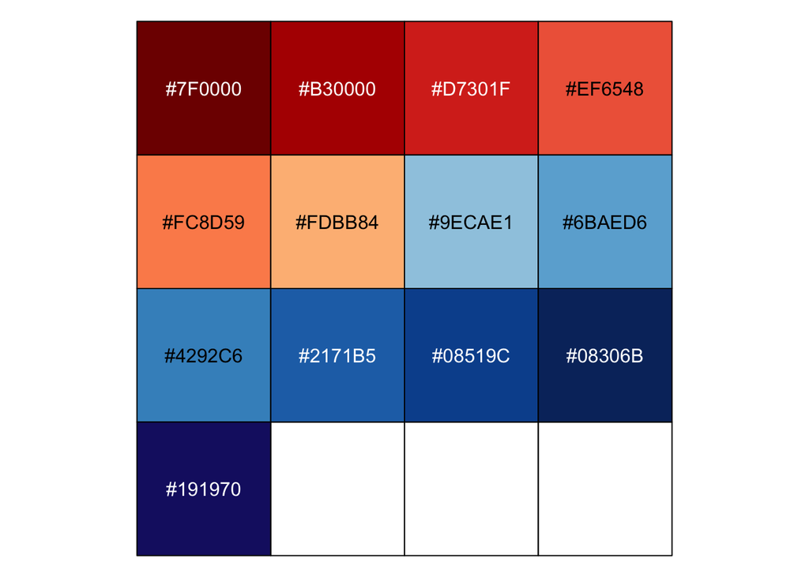

```r
#Creating our color palette
spob2 <- c("#7F0000", "#B30000", "#D7301F", "#EF6548", "#FC8D59", "#FDBB84", "#9ECAE1", "#6BAED6", "#4292C6", "#2171B5", "#08519C", "#08306B", "#191970")
show_col(spob2)
```

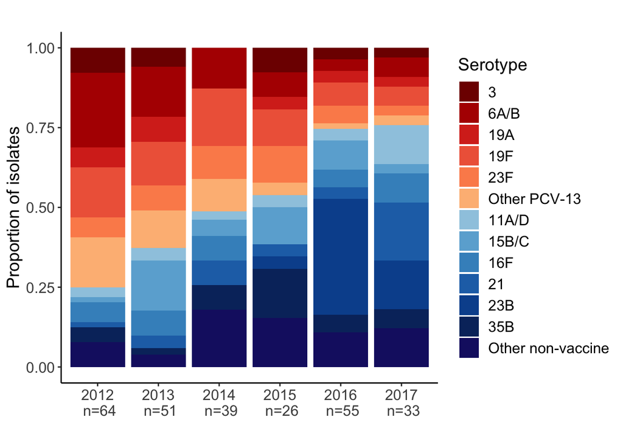

```r
#Creating custom x axis labels with 2 rows (year with n underneath)
xlab <- c("2012\n n=64", "2013\n n=51", "2014\n n=39", "2015\n n=26", "2016\n n=55", "2017\n n=33")

#Creating a figure with 13 colors, using our new spob2 palette
p <- freq %>%
  mutate(serotype = fct_relevel(serotype, "3", "6A/B", "19A", "19F", "23F", "Other PCV-13", "11A/D", "15B/C","16F", "21", "23B", "35B", "Other non-vaccine")) %>%
  ggplot( aes(fill=serotype, x=year, y=newfreq)) + geom_bar(stat= "identity", position = "fill", width = 0.9) +
  scale_fill_manual(values = spob2) +
  scale_y_continuous(labels = waiver()) +
  scale_x_discrete(labels=xlab) +
  labs(title=" ", x="", y="Proportion of isolates", fill = "Serotype")+
  theme_classic() +
  theme(
    plot.title = element_text(size = 16, hjust = 0.5),
    legend.title = element_text(size = 14),
    legend.text = element_text(size = 12),
    legend.position = "right",
    axis.text = element_text(size = 12),
    axis.title = element_text(size = 14))

p
```

## Analysis of serotype trends over time

We will use a multinomial logistic regression model and include age and HIV status as covariates.

### Unadjusted analysis

Two serotype classes (PCV-13 vs non-PCV-13), year as a continuous variable. NOTE: per discussion with MK on 7/27, changed reference group to non-PCV13 for ease of interpretation in the manuscript

```r
sero_cov$ca13 <- relevel(sero_cov$ca13, ref = "Not_PCV13")
test1 <- multinom(ca13 ~ diff_y2, data = sero_cov)
summary(test1)
```

```
## Call:
## multinom(formula = ca13 ~ diff_y2, data = sero_cov)
##
## Coefficients:
##                 Values  Std. Err.
## (Intercept)  1.1369463 0.22834257
## diff_y2     -0.4697704 0.07825673
##
## Residual Deviance: 330.3073
## AIC: 334.3073
```

```r
z1 <- summary(test1)$coefficients/summary(test1)$standard.errors
z1
```

```
## (Intercept)     diff_y2
##    4.979125   -6.002939
```

```r
#Calculate p-values using Wald tests (here z-tests).
#2-tailed z test
p1 <- (1 - pnorm(abs(z1), 0, 1)) * 2
p1
```

```
##  (Intercept)      diff_y2
## 6.387223e-07 1.937775e-09
```

The exponentiated regression coefficients are relative risk ratios for a unit change in the predictor variable

```r
## extract the coefficients from the model and exponentiate
exp(coef(test1))
```

```
## (Intercept)     diff_y2
##   3.1172348   0.6251458
```

```r
#Obtaining 95% CI for our RR
exp(confint(test1))
```

```
##                 2.5 %    97.5 %
## (Intercept) 1.9925258 4.8768013
## diff_y2     0.5362522 0.7287752
```

**Interpretation:**

The relative risk ratio for every 1 year increase since the start of the study for being a PCV13 serotype was 0.63 (95% CI: 0.54, 0.73) –> AKA the risk of a PCV13 serotype compared to a non-PCV13 serotype was 37% lower with each year that passed since the start of the study (P<0.0001).

### Adjusted analysis

```r
sero_cov$ca13 <- relevel(sero_cov$ca13, ref = "Not_PCV13")
test2 <- multinom(ca13 ~ diff_y2 + age_months + HIV_exp, data = sero_cov)
summary(test2)
```

```
## Call:
## multinom(formula = ca13 ~ diff_y2 + age_months + HIV_exp, data = sero_cov)
##
## Coefficients:
##                   Values  Std. Err.
## (Intercept)  0.838257020 0.77733847
## diff_y2     -0.449295028 0.08675562
## age_months   0.008958149 0.02310491
## HIV_expEU    0.181025165 0.75109674
## HIV_expUU    0.216305677 0.71945733
##
## Residual Deviance: 320.5915
## AIC: 330.5915
```

```r
z2 <- summary(test2)$coefficients/summary(test2)$standard.errors
z2
```

```
## (Intercept)     diff_y2  age_months   HIV_expEU   HIV_expUU
##   1.0783681  -5.1788577   0.3877163   0.2410144   0.3006512
```

Exponentiated coefficients and p-values

```r
## extract the coefficients from the model and exponentiate
exp(coef(test2))
```

```
## (Intercept)     diff_y2  age_months   HIV_expEU   HIV_expUU
##   2.3123331   0.6380778   1.0089984   1.1984453   1.2414818
```

```r
#Obtaining 95% CI for our RR
exp(confint(test2))
```

```
##                 2.5 %     97.5 %
## (Intercept) 0.5039398 10.6101642
## diff_y2     0.5383034  0.7563454
## age_months  0.9643253  1.0557410
## HIV_expEU   0.2749689  5.2233958
## HIV_expUU   0.3030660  5.0856159
```

```r
#Calculate p-values using Wald tests (here z-tests).
#2-tailed z test
p2 <- (1 - pnorm(abs(z2), 0, 1)) * 2
p2
```

```
##  (Intercept)      diff_y2   age_months    HIV_expEU    HIV_expUU
## 2.808695e-01 2.232486e-07 6.982260e-01 8.095439e-01 7.636805e-01
```

**Interpretation:**

*After adjusting for age and HIV exposure status (exposed-infected, exposed-uninfected, unexposed-uninfected):*

The relative risk ratio for every 1 year increase since the start of the study for being a PCV13 serotype was 0.64 (95% CI: 0.54, 0.76) –> AKA the adjusted risk of a PCV13 serotype compared to a non-PCV13 serotype was 36% lower with each year that passed since the start of the study (P < 0.0001).

## Distribution of strains in case-control study

```r
casecon <- subset(sero_cov, subject == "Case" | subject == "Control")
#Our new data frame now only contains cases and controls, but the "subject" variable retained the micro level too, even though it does not exist in this new dataframe. To fix this, do the following:
casecon$subject <- factor(casecon$subject)
#Check to make sure we are only working with 2 levels:
table(casecon$subject) #Success! We have a lot more cases than controls included (149 vs 39)
```

```
##
##    Case Control
##     149      39
```

```r
table(casecon$subject, casecon$ca13)
```

```
##
##           Not_PCV13 PCV13
##   Case           60    89
##   Control        13    26
```

```r
prop.table(table(casecon$ca13, casecon$subject), 2)       #Proportion of serotype class appears roughly similar
```

```
##
##                  Case   Control
##   Not_PCV13 0.4026846 0.3333333
##   PCV13     0.5973154 0.6666667
```

```r
summary(table(casecon$ca13, casecon$subject))
```

```
## Number of cases in table: 188
## Number of factors: 2
## Test for independence of all factors:
##  Chisq = 0.6259, df = 1, p-value = 0.4289
```

```r
  #No significant difference by Chi-squared test
```